# Jupyter notebook a programovací jazyk R

## Otestování základní funkcionality kernelu jazyka R

```r
print("Hello world!")
```

```
[1] "Hello world!"
```

```r
"Hello world!"
```

'Hello world!'

## Zobrazení nápovědy

```r
help(sort)
```

### Zobrazení příkladu použití

```r
example(sort)
```

```
sort> require(stats)

sort> x <- swiss$Education[1:25]

sort> x; sort(x); sort(x, partial = c(10, 15))
 [1] 12  9  5  7 15  7  7  8  7 13  6 12  7 12  5  2  8 28 20  9 10  3 12  6  1
 [1]  1  2  3  5  5  6  6  7  7  7  7  7  8  8  9  9 10 12 12 12 12 13 15 20 28
 [1]  3  2  5  5  1  6  6  7  7  7  7  8  7  8  9  9 10 12 12 12 12 20 28 13 15

sort> ## illustrate 'stable' sorting (of ties):
sort> sort(c(10:3, 2:12), method = "shell", index.return = TRUE) # is stable
$x
 [1]  2  3  3  4  4  5  5  6  6  7  7  8  8  9  9 10 10 11 12

$ix
 [1]  9  8 10  7 11  6 12  5 13  4 14  3 15  2 16  1 17 18 19


sort> ## $x : 2  3  3  4  4  5  5  6  6  7  7  8  8  9  9 10 10 11 12
sort> ## $ix: 9  8 10  7 11  6 12  5 13  4 14  3 15  2 16  1 17 18 19
sort> sort(c(10:3, 2:12), method = "quick", index.return = TRUE) # is not
$x
 [1]  2  3  3  4  4  5  5  6  6  7  7  8  8  9  9 10 10 11 12

$ix
 [1]  9  8 10 11  7  6 12  5 13  4 14  3 15  2 16 17  1 18 19


sort> ## $x : 2  3  3  4  4  5  5  6  6  7  7  8  8  9  9 10 10 11 12
sort> ## $ix: 9 10  8  7 11  6 12  5 13  4 14  3 15 16  2 17  1 18 19
sort>
sort> x <- c(1:3, 3:5, 10)

sort> is.unsorted(x)                  # FALSE: is sorted
[1] FALSE

sort> is.unsorted(x, strictly = TRUE) # TRUE : is not (and cannot be)
[1] TRUE

sort>                                 # sorted strictly
```

[output cut: 11 more lines]

```
sort> ##D }
sort> ##D rbind(ShellSort = c1, QuickSort = c2)
sort> ##D cat("Speedup factor of quick sort():\n")
sort> ##D summary({qq <- c1 / c2; qq[is.finite(qq)]})
sort> ##D
sort> ##D ## A larger test
sort> ##D x <- rnorm(1e7)
sort> ##D system.time(x1 <- sort(x, method = "shell"))
sort> ##D system.time(x2 <- sort(x, method = "quick"))
sort> ##D system.time(x3 <- sort(x, method = "radix"))
sort> ##D stopifnot(identical(x1, x2))
sort> ##D stopifnot(identical(x1, x3))
sort> ## End(Not run)
sort>
sort>
```

## Práce s vektory

Se základními konstruktory vektorů jsme se již v tomto seriálu seznámili, takže si nyní pouze připomeňme, že existuje hned několik způsobů konstrukce nového vektoru. V případě, že má vektor obsahovat jen jedinou hodnotu, je vytvoření takového vektoru jednoduché a přímočaré, protože vlastní zápis hodnoty (typicky čísla) již představuje skalární hodnotu, která se však chová jako vektor (má délku rovnou jedné, může se používat v operacích, kde se očekávají vektory atd.):

```r
42
```

42

O tom, jakého typu je takový skalár nebo vektor, se můžeme přesvědčit zavoláním funkce class:

```r
class(42)
```

'numeric'

Vektor s obecnými prvky se vytvoří konstruktorem nazvaným `c`, což je funkce, které se předají hodnoty jednotlivých prvků:

```r
a <- c(1,2,3,4)
```

```r
class(a)
```

'numeric'

Prvky samozřejmě nemusí být pouze celými čísly, ale například i hodnotami s plovoucí řádovou čárkou:

```r
b <- c(1.2, 2.3, 3.4)
class(b)
```

'numeric'

Nakonec si vyzkoušíme vytvoření vektoru obsahujícího pravdivostní hodnoty `TRUE` a `FALSE`:

```r
l <- c(TRUE, FALSE, TRUE)
class(l)
```

'logical'

Sekvence hodnot:

```r
data <- 1:12
```

```r
data
```

1. 1

2. 2

3. 3

4. 4

5. 5

6. 6

7. 7

8. 8

9. 9

10. 10

11. 11

12. 12

Porovnání dvou vektorů (druhý vektor s jediným prvkem je rozšířen na velikost prvního vektoru):

```r
data < 6
```

1. TRUE

2. TRUE

3. TRUE

4. TRUE

5. TRUE

6. FALSE

7. FALSE

8. FALSE

9. FALSE

10. FALSE

11. FALSE

12. FALSE

## Matice

Pro vytvoření matice se používá konstruktor nazvaný matrix, kterému se předá vektor s daty (hodnotami prvků), počet řádků a počet sloupců (popř. obráceně):

```r
m1 <- matrix(data, nrow=1, ncol=12)
```

```r
m1
```

A matrix: 1 × 12 of type int

| 1 | 2 | 3 | 4 | 5 | 6 | 7 | 8 | 9 | 10 | 11 | 12 |
| --- | --- | --- | --- | --- | --- | --- | --- | --- | --- | --- | --- |

```r
m2 <- matrix(data, nrow=3, ncol=4)
```

```r
m2
```

A matrix: 3 × 4 of type int

| 1 | 4 | 7 | 10 |
| --- | --- | --- | --- |
| 2 | 5 | 8 | 11 |
| 3 | 6 | 9 | 12 |

```r
m3 <- matrix(data, nrow=4, ncol=3)
```

```r
m3
```

A matrix: 4 × 3 of type int

| 1 | 5 | 9 |
| --- | --- | --- |
| 2 | 6 | 10 |
| 3 | 7 | 11 |
| 4 | 8 | 12 |

### Zaplnění matice po řádcích nebo po sloupcích

V konstruktoru `matrix` je možné nepovinným parametrem (logickou hodnotou) `byrow` určit, zda bude matice zaplňována po řádcích nebo po sloupcích.

```r
data <- 1:12

m1 <- matrix(data, nrow=1, ncol=12, byrow=TRUE)
m1

m2 <- matrix(data, nrow=2, ncol=6, byrow=TRUE)
m2

m3 <- matrix(data, nrow=3, ncol=4, byrow=TRUE)
m3

m4 <- matrix(data, nrow=4, ncol=3, byrow=TRUE)
m4

m5 <- matrix(data, nrow=6, ncol=2, byrow=TRUE)
m5

m6 <- matrix(data, nrow=12, ncol=1, byrow=TRUE)
m6
```

A matrix: 1 × 12 of type int

| 1 | 2 | 3 | 4 | 5 | 6 | 7 | 8 | 9 | 10 | 11 | 12 |
| --- | --- | --- | --- | --- | --- | --- | --- | --- | --- | --- | --- |

A matrix: 2 × 6 of type int

| 1 | 2 | 3 | 4 | 5 | 6 |
| --- | --- | --- | --- | --- | --- |
| 7 | 8 | 9 | 10 | 11 | 12 |

A matrix: 3 × 4 of type int

| 1 | 2 | 3 | 4 |
| --- | --- | --- | --- |
| 5 | 6 | 7 | 8 |
| 9 | 10 | 11 | 12 |

A matrix: 4 × 3 of type int

| 1 | 2 | 3 |
| --- | --- | --- |
| 4 | 5 | 6 |
| 7 | 8 | 9 |
| 10 | 11 | 12 |

A matrix: 6 × 2 of type int

| 1 | 2 |
| --- | --- |
| 3 | 4 |
| 5 | 6 |
| 7 | 8 |
| 9 | 10 |
| 11 | 12 |

A matrix: 12 × 1 of type int

| 1 |
| --- |
| 2 |
| 3 |
| 4 |
| 5 |
| 6 |
| 7 |
| 8 |
| 9 |
| 10 |
| 11 |
| 12 |

### Pojmenování řádků a sloupců matice

Konstruktoru matrix postačuje předat v pojmenovaném parametru `dimnames` seznam vektorů, přičemž první vektor v seznamu obsahuje jména řádků a druhý vektor jména sloupců. Se seznamy jsme se sice prozatím nesetkali, ale ze zdrojového kódu dalšího demonstračního příkladu je patrné, že je jejich konstrukce pomocí `list` přímočará:

```r
data <- 1:9
dimension.names <- list(
    c("x", "y", "z"),
    c("u", "v", "w"))

m33 <- matrix(data, nrow=3, ncol=3, dimnames=dimension.names)
m33
```

A matrix: 3 × 3 of type int

|  | u | v | w |
| --- | --- | --- | --- |
| x | 1 | 4 | 7 |
| y | 2 | 5 | 8 |
| z | 3 | 6 | 9 |

### Tisk tabulky s názvy měsíců

```r
matrix(
  month.abb[c(12, 1:11)],
  nrow = 3,
  dimnames = list(
    c("start", "middle", "end"),
    c("Winter", "Spring", "Summer", "Fall")
  )
)
```

A matrix: 3 × 4 of type chr

|  | Winter | Spring | Summer | Fall |
| --- | --- | --- | --- | --- |
| start | Dec | Mar | Jun | Sep |
| middle | Jan | Apr | Jul | Oct |
| end | Feb | May | Aug | Nov |

### Maticový součin

```r
data <- 1:25

m1 <- matrix(data, nrow=5, ncol=5)
m1

m2 <- diag(5)
m2

m1 %*% m2

m2[3,3] <- 10
m1 %*% m2
```

A matrix: 5 × 5 of type int

| 1 | 6 | 11 | 16 | 21 |
| --- | --- | --- | --- | --- |
| 2 | 7 | 12 | 17 | 22 |
| 3 | 8 | 13 | 18 | 23 |
| 4 | 9 | 14 | 19 | 24 |
| 5 | 10 | 15 | 20 | 25 |

A matrix: 5 × 5 of type dbl

| 1 | 0 | 0 | 0 | 0 |
| --- | --- | --- | --- | --- |
| 0 | 1 | 0 | 0 | 0 |
| 0 | 0 | 1 | 0 | 0 |
| 0 | 0 | 0 | 1 | 0 |
| 0 | 0 | 0 | 0 | 1 |

A matrix: 5 × 5 of type dbl

| 1 | 6 | 11 | 16 | 21 |
| --- | --- | --- | --- | --- |
| 2 | 7 | 12 | 17 | 22 |
| 3 | 8 | 13 | 18 | 23 |
| 4 | 9 | 14 | 19 | 24 |
| 5 | 10 | 15 | 20 | 25 |

A matrix: 5 × 5 of type dbl

| 1 | 6 | 110 | 16 | 21 |
| --- | --- | --- | --- | --- |
| 2 | 7 | 120 | 17 | 22 |
| 3 | 8 | 130 | 18 | 23 |
| 4 | 9 | 140 | 19 | 24 |
| 5 | 10 | 150 | 20 | 25 |

### Výpočet inverzní matice

```r
data <- c(2, 3, 2, 2)

m1 <- matrix(data, nrow=2, ncol=2)
m1
solve(m1)

m2 <- diag(5)
m2
solve(m2)

m3 <- diag(5)
m3[3, 3] = 42
m3
solve(m3)
```

A matrix: 2 × 2 of type dbl

| 2 | 2 |
| --- | --- |
| 3 | 2 |

A matrix: 2 × 2 of type dbl

| -1.0 | 1 |
| --- | --- |
| 1.5 | -1 |

A matrix: 5 × 5 of type dbl

| 1 | 0 | 0 | 0 | 0 |
| --- | --- | --- | --- | --- |
| 0 | 1 | 0 | 0 | 0 |
| 0 | 0 | 1 | 0 | 0 |
| 0 | 0 | 0 | 1 | 0 |
| 0 | 0 | 0 | 0 | 1 |

A matrix: 5 × 5 of type dbl

| 1 | 0 | 0 | 0 | 0 |
| --- | --- | --- | --- | --- |
| 0 | 1 | 0 | 0 | 0 |
| 0 | 0 | 1 | 0 | 0 |
| 0 | 0 | 0 | 1 | 0 |
| 0 | 0 | 0 | 0 | 1 |

A matrix: 5 × 5 of type dbl

| 1 | 0 | 0 | 0 | 0 |
| --- | --- | --- | --- | --- |
| 0 | 1 | 0 | 0 | 0 |
| 0 | 0 | 42 | 0 | 0 |
| 0 | 0 | 0 | 1 | 0 |
| 0 | 0 | 0 | 0 | 1 |

A matrix: 5 × 5 of type dbl

| 1 | 0 | 0.00000000 | 0 | 0 |
| --- | --- | --- | --- | --- |
| 0 | 1 | 0.00000000 | 0 | 0 |
| 0 | 0 | 0.02380952 | 0 | 0 |
| 0 | 0 | 0.00000000 | 1 | 0 |
| 0 | 0 | 0.00000000 | 0 | 1 |

## Datové rámce

### Konstrukce datového rámce

```r
ids = c(1:9)
names = c("C", "Java", "Python", "C++", "C#", "Visual Basic", "JavaScript", "PHP", "R")
usages = c(15.95, 13.48, 10.47, 7.11, 4.58, 4.12, 2.54, 2.49, 2.37)
changes = c(0.74, -3.18, 0.59, 1.48, 1.18, 0.83, 0.41, 0.62, 1.33)
```

```r
languages <- data.frame(
    ids,
    names,
    usages,
    changes
)

languages
```

A data.frame: 9 × 4

| ids <int> | names <chr> | usages <dbl> | changes <dbl> |
| --- | --- | --- | --- |
| 1 | C | 15.95 | 0.74 |
| 2 | Java | 13.48 | -3.18 |
| 3 | Python | 10.47 | 0.59 |
| 4 | C++ | 7.11 | 1.48 |
| 5 | C# | 4.58 | 1.18 |
| 6 | Visual Basic | 4.12 | 0.83 |
| 7 | JavaScript | 2.54 | 0.41 |
| 8 | PHP | 2.49 | 0.62 |
| 9 | R | 2.37 | 1.33 |

```r
languages2 <- data.frame(
    id = ids,
    name = names,
    usage = usages,
    change = changes
)

languages2
```

A data.frame: 9 × 4

| id <int> | name <chr> | usage <dbl> | change <dbl> |
| --- | --- | --- | --- |
| 1 | C | 15.95 | 0.74 |
| 2 | Java | 13.48 | -3.18 |
| 3 | Python | 10.47 | 0.59 |
| 4 | C++ | 7.11 | 1.48 |
| 5 | C# | 4.58 | 1.18 |
| 6 | Visual Basic | 4.12 | 0.83 |
| 7 | JavaScript | 2.54 | 0.41 |
| 8 | PHP | 2.49 | 0.62 |
| 9 | R | 2.37 | 1.33 |

### Neexistující hodnoty ve vstupních datech

```r
ids = c(1:9)
names = c("C", "Java", "Python", "C++", "C#", "Visual Basic", NA, "PHP", "R")
usages = c(15.95, 13.48, 10.47, 7.11, 4.58, 4.12, NA, 2.49, 2.37)
changes = c(0.74, NA, 0.59, 1.48, 1.18, 0.83, 0.41, NA, 1.33)
```

```r
languages3 <- data.frame(
   id = ids,
   name = names,
   usage = usages,
   change = changes
)

languages3
```

A data.frame: 9 × 4

| id <int> | name <chr> | usage <dbl> | change <dbl> |
| --- | --- | --- | --- |
| 1 | C | 15.95 | 0.74 |
| 2 | Java | 13.48 | NA |
| 3 | Python | 10.47 | 0.59 |
| 4 | C++ | 7.11 | 1.48 |
| 5 | C# | 4.58 | 1.18 |
| 6 | Visual Basic | 4.12 | 0.83 |
| 7 | NA | NA | 0.41 |
| 8 | PHP | 2.49 | NA |
| 9 | R | 2.37 | 1.33 |

### Výpočet a výpis statistických informací o datovém rámci

```r
languages <- data.frame(
   id = c (1:9),
   name = c("C", "Java", "Python", "C++", "C#", "Visual Basic", "JavaScript", "PHP", "R"),
   usage = c(15.95, 13.48, 10.47, 7.11, 4.58, 4.12, 2.54, 2.49, 2.37),
   change = c(0.74, -3.18, 0.59, 1.48, 1.18, 0.83, 0.41, 0.62, 1.33),
   stringsAsFactors = FALSE
)

summary(languages)
```

```
       id        name               usage            change
 Min.   :1   Length:9           Min.   : 2.370   Min.   :-3.1800
 1st Qu.:3   Class :character   1st Qu.: 2.540   1st Qu.: 0.5900
 Median :5   Mode  :character   Median : 4.580   Median : 0.7400
 Mean   :5                      Mean   : 7.012   Mean   : 0.4444
 3rd Qu.:7                      3rd Qu.:10.470   3rd Qu.: 1.1800
 Max.   :9                      Max.   :15.950   Max.   : 1.4800
```

### Konverze datového rámce na matici

V dalším demonstračním příkladu si ukážeme jednu poměrně často prováděnou operaci – konverzi datového rámce na „obyčejnou“ matici. To pochopitelně není zcela bezproblémové, protože všechny prvky matice musí být stejného datového typu. Pokud jsou řetězce reprezentovány formou faktorů, budou převedeny na celá čísla (indexy):

```r
languages <- data.frame(
   id = c(1:9),
   name = c("C", "Java", "Python", "C++", "C#", "Visual Basic", "JavaScript", "PHP", "R"),
   usage = c(15.95, 13.48, 10.47, 7.11, 4.58, 4.12, 2.54, 2.49, 2.37),
   change = c(0.74, -3.18, 0.59, 1.48, 1.18, 0.83, 0.41, 0.62, 1.33)
)

languages


m <- data.matrix(languages)
class(m)
m
```

A data.frame: 9 × 4

| id <int> | name <chr> | usage <dbl> | change <dbl> |
| --- | --- | --- | --- |
| 1 | C | 15.95 | 0.74 |
| 2 | Java | 13.48 | -3.18 |
| 3 | Python | 10.47 | 0.59 |
| 4 | C++ | 7.11 | 1.48 |
| 5 | C# | 4.58 | 1.18 |
| 6 | Visual Basic | 4.12 | 0.83 |
| 7 | JavaScript | 2.54 | 0.41 |
| 8 | PHP | 2.49 | 0.62 |
| 9 | R | 2.37 | 1.33 |

1. 'matrix'

2. 'array'

A matrix: 9 × 4 of type dbl

| id | name | usage | change |
| --- | --- | --- | --- |
| 1 | 1 | 15.95 | 0.74 |
| 2 | 4 | 13.48 | -3.18 |
| 3 | 7 | 10.47 | 0.59 |
| 4 | 3 | 7.11 | 1.48 |
| 5 | 2 | 4.58 | 1.18 |
| 6 | 9 | 4.12 | 0.83 |
| 7 | 5 | 2.54 | 0.41 |
| 8 | 6 | 2.49 | 0.62 |
| 9 | 8 | 2.37 | 1.33 |

### Datový rámec získaný z matice – jednoduchý kalendář

```r
m <- matrix(
  month.abb[c(12, 1:11)],
  nrow = 3,
  dimnames = list(
    c("start", "middle", "end"),
    c("Winter", "Spring", "Summer", "Fall")
  )
)

class(m)
m

df <- as.data.frame(m)
class(df)
df
```

1. 'matrix'

2. 'array'

A matrix: 3 × 4 of type chr

|  | Winter | Spring | Summer | Fall |
| --- | --- | --- | --- | --- |
| start | Dec | Mar | Jun | Sep |
| middle | Jan | Apr | Jul | Oct |
| end | Feb | May | Aug | Nov |

'data.frame'

A data.frame: 3 × 4

|  | Winter <chr> | Spring <chr> | Summer <chr> | Fall <chr> |
| --- | --- | --- | --- | --- |
| start | Dec | Mar | Jun | Sep |
| middle | Jan | Apr | Jul | Oct |
| end | Feb | May | Aug | Nov |

## Datové rámce a grafy

### Sloupcový graf s hodnotami vyčtenými z datového rámce

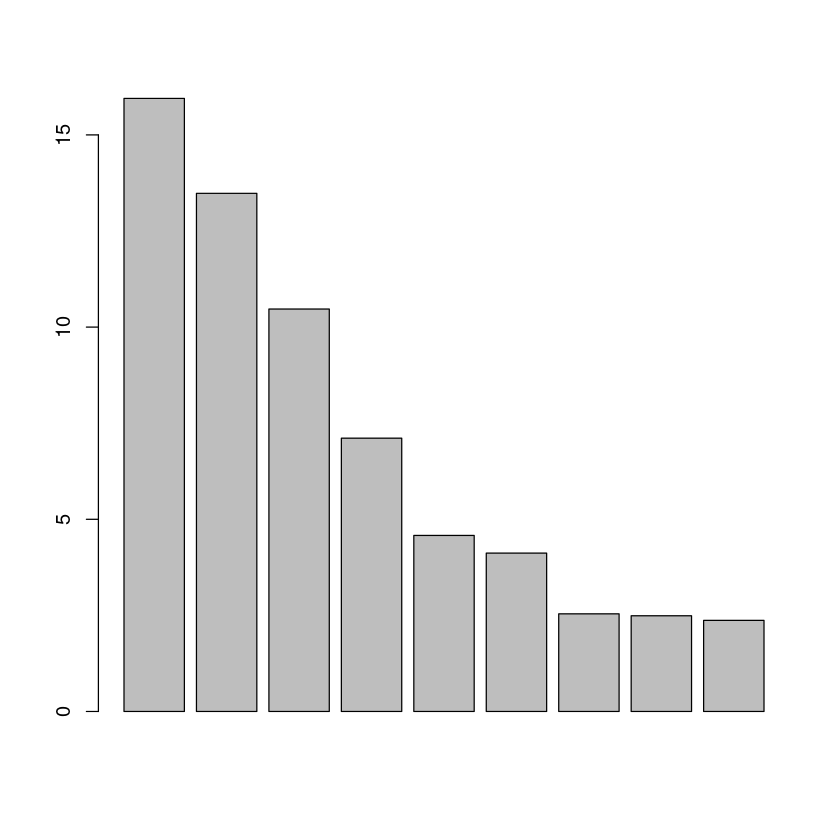

```r
languages <- data.frame(
   id = c(1:9),
   name = c("C", "Java", "Python", "C++", "C#", "Visual Basic", "JavaScript", "PHP", "R"),
   usage = c(15.95, 13.48, 10.47, 7.11, 4.58, 4.12, 2.54, 2.49, 2.37),
   change = c(0.74, -3.18, 0.59, 1.48, 1.18, 0.83, 0.41, 0.62, 1.33)
)

barplot(languages$usage)
```

### Přidání popisku horizontální osy do grafu

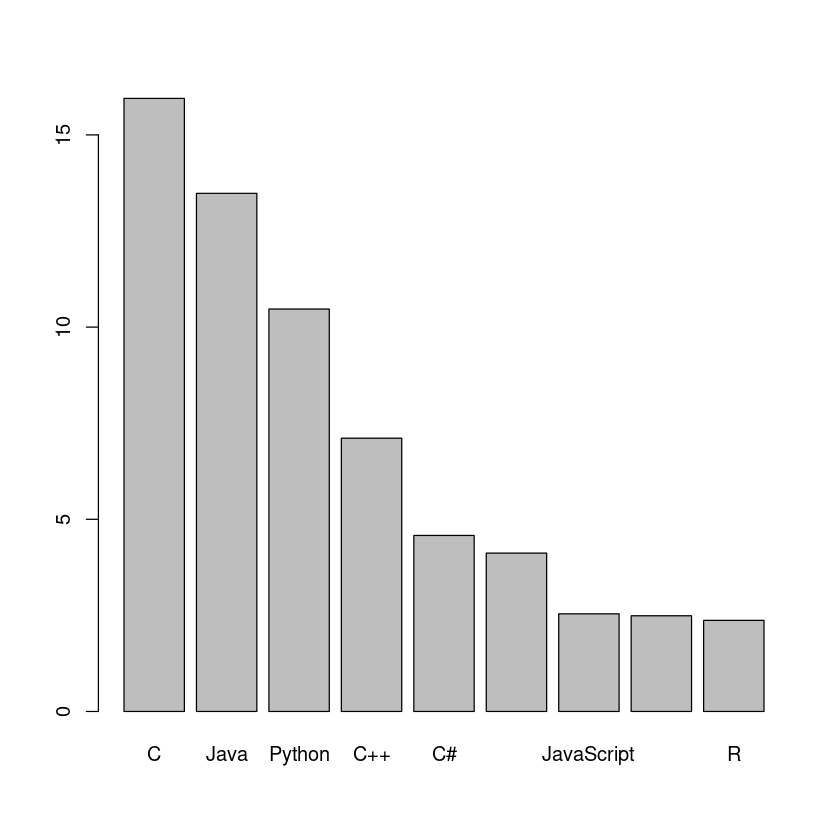

```r
languages <- data.frame(
   id = c(1:9),
   name = c("C", "Java", "Python", "C++", "C#", "Visual Basic", "JavaScript", "PHP", "R"),
   usage = c(15.95, 13.48, 10.47, 7.11, 4.58, 4.12, 2.54, 2.49, 2.37),
   change = c(0.74, -3.18, 0.59, 1.48, 1.18, 0.83, 0.41, 0.62, 1.33)
)

barplot(languages$usage, names.arg=languages$name)
```

### Úprava stylu zobrazení grafu

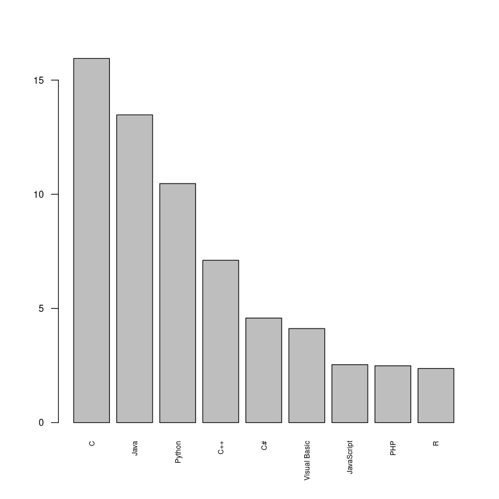

```r
languages <- data.frame(
   id = c(1:9),
   name = c("C", "Java", "Python", "C++", "C#", "Visual Basic", "JavaScript", "PHP", "R"),
   usage = c(15.95, 13.48, 10.47, 7.11, 4.58, 4.12, 2.54, 2.49, 2.37),
   change = c(0.74, -3.18, 0.59, 1.48, 1.18, 0.83, 0.41, 0.62, 1.33)
)

barplot(languages$usage, names.arg=languages$name,
     cex.axis = 0.8,
     cex.names = 0.6,
     las=2)
```

### Přidání liniového grafu do grafu sloupcového

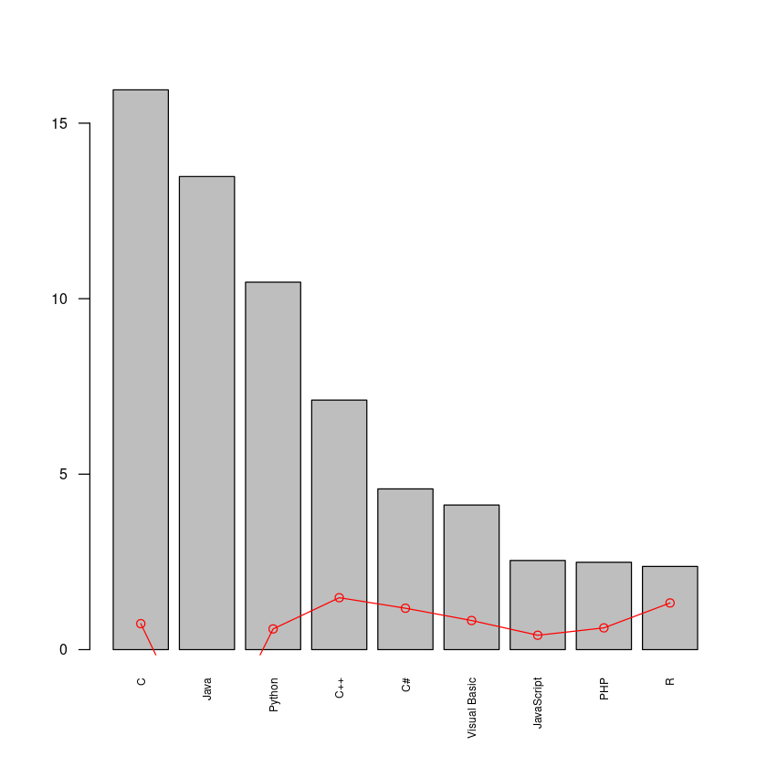

```r
languages <- data.frame(
   id = c(1:9),
   name = c("C", "Java", "Python", "C++", "C#", "Visual Basic", "JavaScript", "PHP", "R"),
   usage = c(15.95, 13.48, 10.47, 7.11, 4.58, 4.12, 2.54, 2.49, 2.37),
   change = c(0.74, -3.18, 0.59, 1.48, 1.18, 0.83, 0.41, 0.62, 1.33)
)

plt <- barplot(languages$usage, names.arg=languages$name,
     cex.axis = 0.8,
     cex.names = 0.6,
     las=2)

lines(plt, languages$change, type="o", col="red")
```

### Sloupcový graf se dvěma skupinami sloupců

```
        [,1]  [,2]  [,3] [,4] [,5] [,6] [,7] [,8] [,9]
usage  15.95 13.48 10.47 7.11 4.58 4.12 2.54 2.49 2.37
change  0.74 -3.18  0.59 1.48 1.18 0.83 0.41 0.62 1.33
```

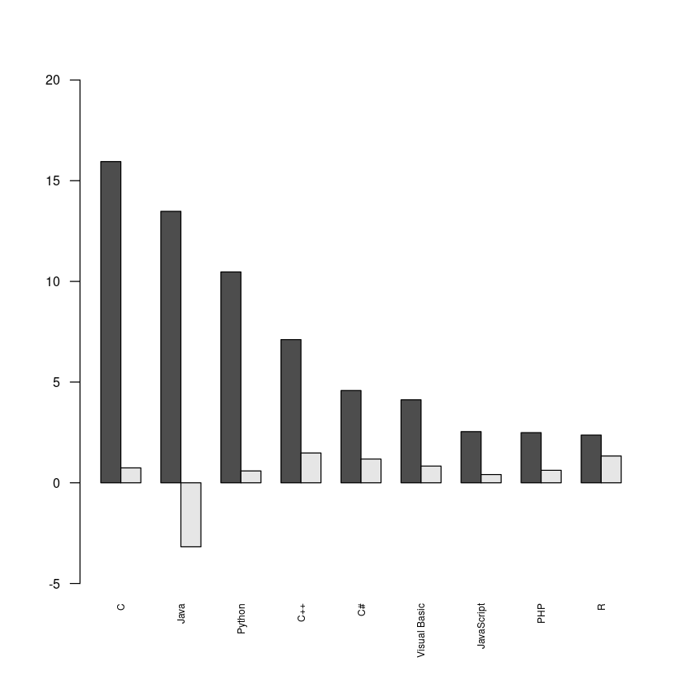

```r
languages <- data.frame(
   id = c(1:9),
   name = c("C", "Java", "Python", "C++", "C#", "Visual Basic", "JavaScript", "PHP", "R"),
   usage = c(15.95, 13.48, 10.47, 7.11, 4.58, 4.12, 2.54, 2.49, 2.37),
   change = c(0.74, -3.18, 0.59, 1.48, 1.18, 0.83, 0.41, 0.62, 1.33)
)

data=t(languages[, c("usage", "change")])
print(data)

barplot(data, names.arg=languages$name,
     ylim=c(-5, 20),
     cex.axis = 0.8,
     cex.names = 0.6,
     las=2,
     beside=T)
```

### Grafy průběhů funkcí

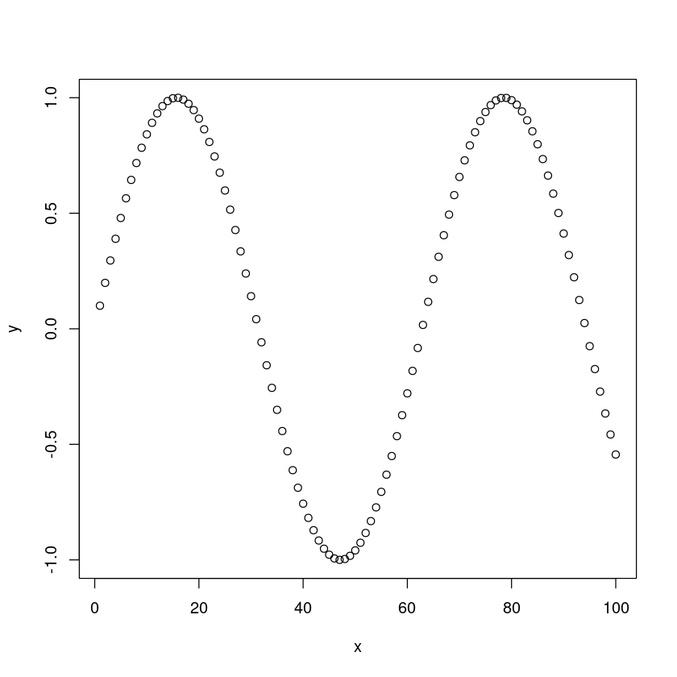

```r
x <- 1:100
y <- sin(x/10)
plot(x,y)
```

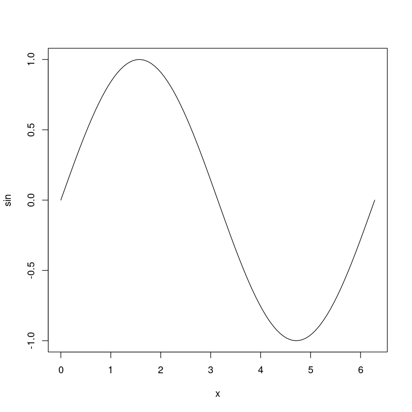

```r
plot(sin, from=0, to=2*pi)
```

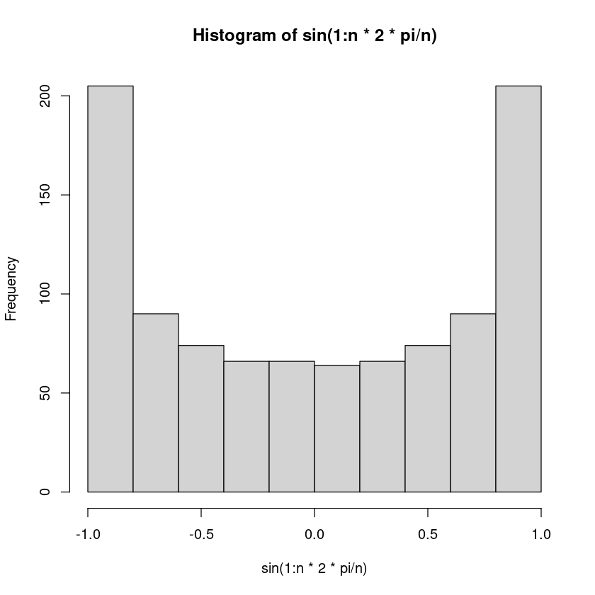

```r
n <- 1000
hist(sin(1:n * 2*pi/n))
```

```r
install.packages("ggplot2")
```

```r
x <- 1:6  # Create vector.
y <- x^2  # Create vector by formula.
model <- lm(y ~ x)
print(model)
```

```
Call:
lm(formula = y ~ x)

Coefficients:
(Intercept)            x
     -9.333        7.000
```

```r
summary(model)
```

```
Call:
lm(formula = y ~ x)

Residuals:
      1       2       3       4       5       6
 3.3333 -0.6667 -2.6667 -2.6667 -0.6667  3.3333

Coefficients:
            Estimate Std. Error t value Pr(>|t|)
(Intercept)  -9.3333     2.8441  -3.282 0.030453 *
x             7.0000     0.7303   9.585 0.000662 ***
---
Signif. codes:  0 ‘***’ 0.001 ‘**’ 0.01 ‘*’ 0.05 ‘.’ 0.1 ‘ ’ 1

Residual standard error: 3.055 on 4 degrees of freedom
Multiple R-squared:  0.9583,	Adjusted R-squared:  0.9478
F-statistic: 91.88 on 1 and 4 DF,  p-value: 0.000662
```

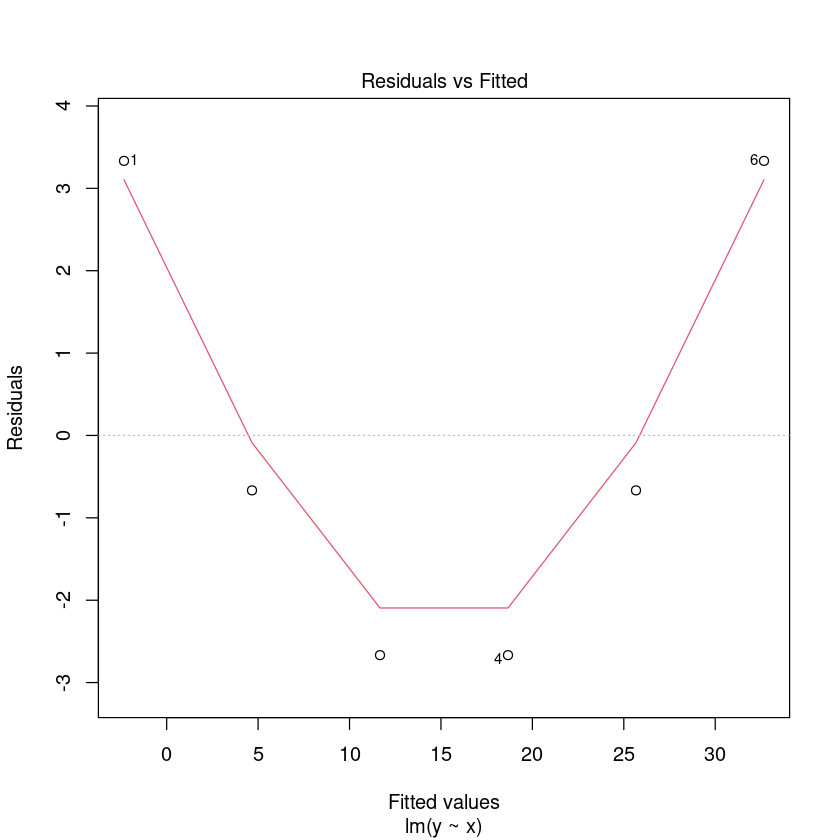

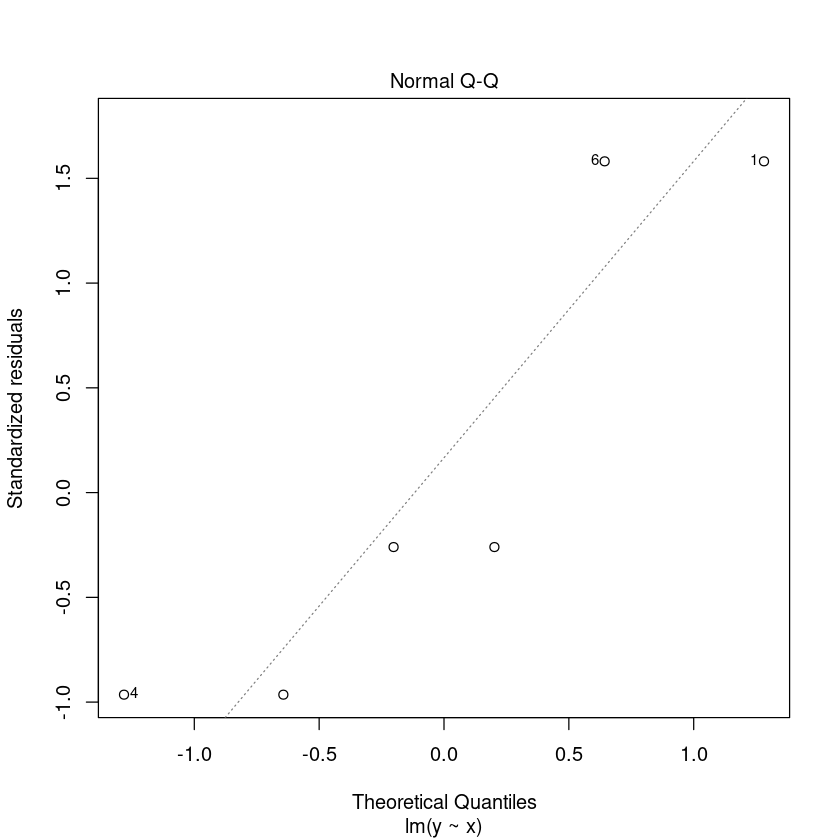

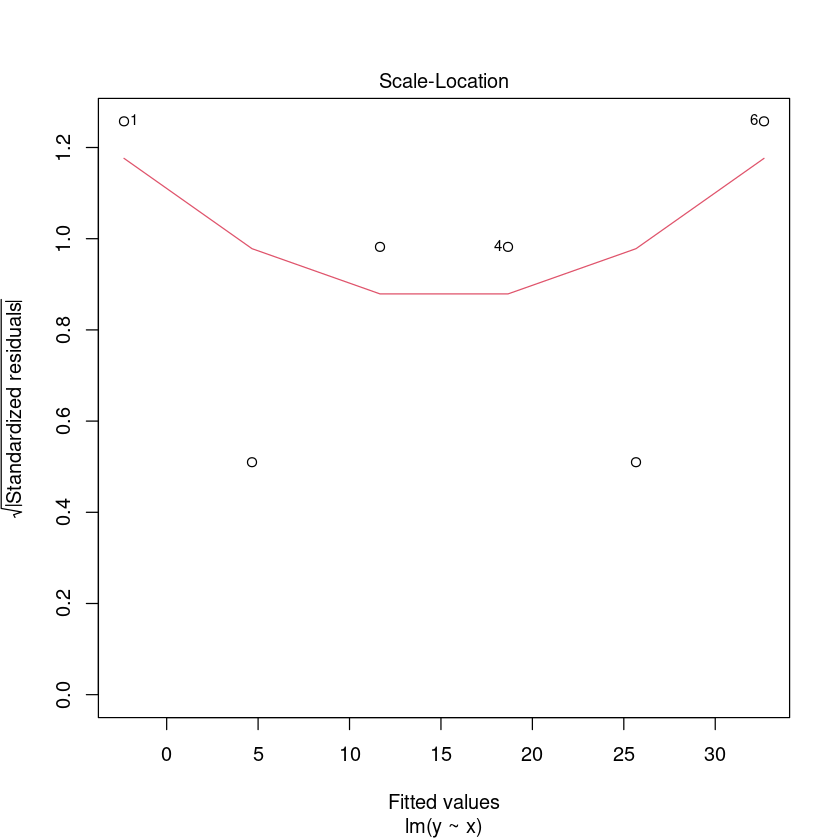

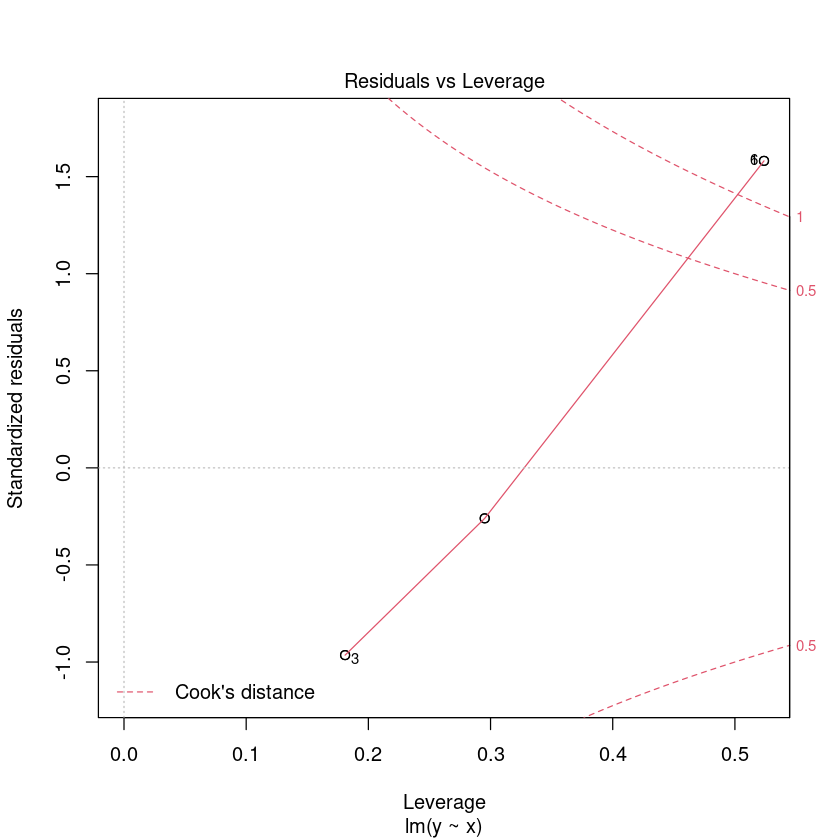

```r
plot(model)
```

## Typy vykreslení úseček

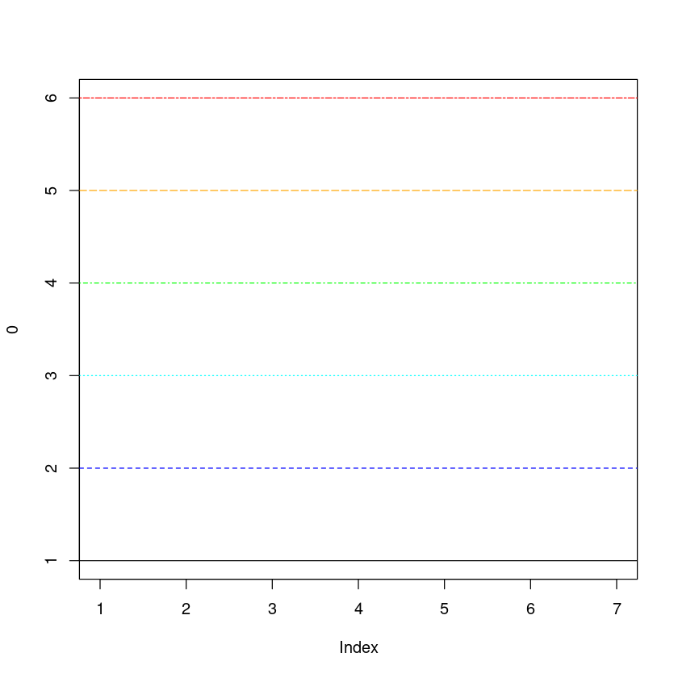

```r
plot(0, xlim=c(1,7), ylim=c(1,6))

abline(h=1, lwd=1, lty=1, col="black")
abline(h=2, lwd=1, lty=2, col="blue")
abline(h=3, lwd=1, lty=3, col="cyan")
abline(h=4, lwd=1, lty=4, col="green")
abline(h=5, lwd=1, lty=5, col="orange")
abline(h=6, lwd=1, lty=6, col="red")
```

## Regresní přímka v diagramu

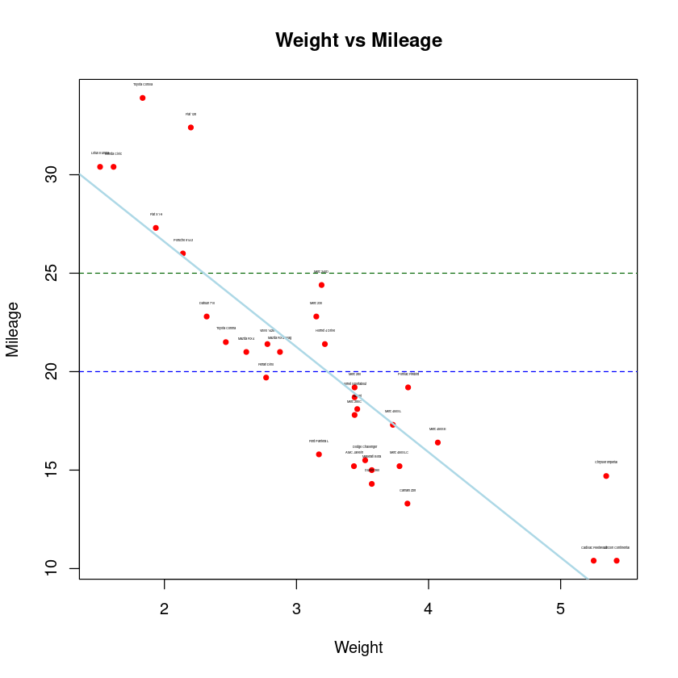

```r
input <- mtcars

plot(x = input$wt,y = input$mpg,
   xlab = "Weight",
   ylab = "Mileage",
   main = "Weight vs Mileage",
   pch=20, col="red"
)

text(input$wt+0, input$mpg+0.7, rownames(input), cex=0.2)

abline(20,0,col='blue', lty=2, lwd=1)
abline(25,0,col='darkgreen', lty=2, lwd=1)

regression <- lm(input$mpg~input$wt)
abline(reg=regression, col='lightblue', lwd=2)
```

## Zakreslení statistických hodnot (průměru, směrodatné odchylky) do diagramu

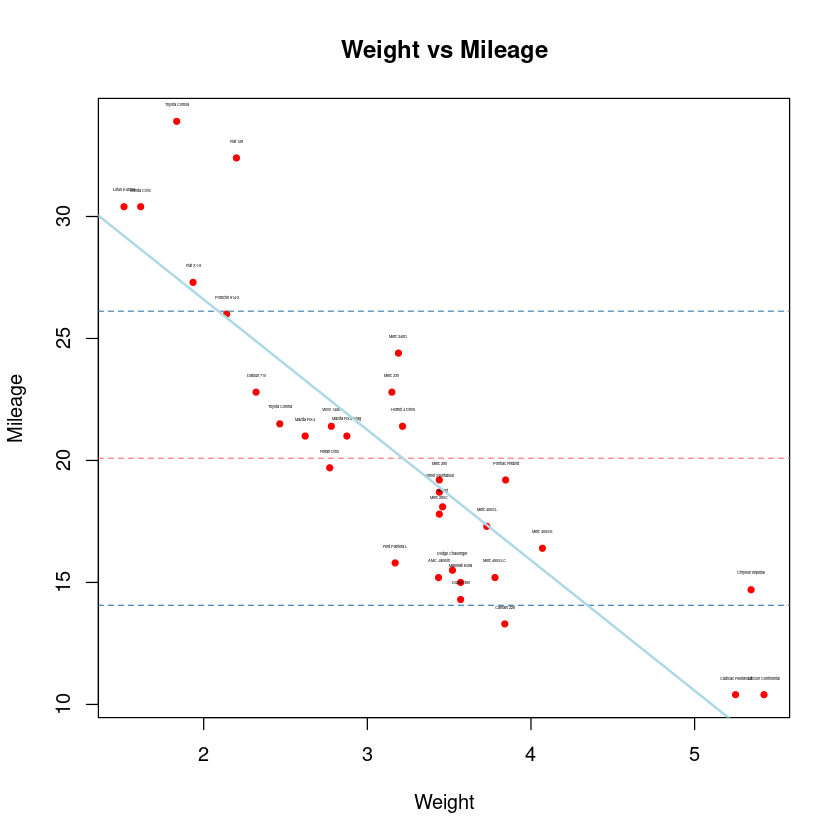

```r
input <- mtcars

plot(x = input$wt,y = input$mpg,
   xlab = "Weight",
   ylab = "Mileage",
   main = "Weight vs Mileage",
   pch=20, col="red"
)

text(input$wt+0, input$mpg+0.7, rownames(input), cex = 0.2)

abline(h = mean(input$mpg), col = '#ff8080', lwd = 1, lty = 2)

abline(h = mean(input$mpg) + sd(input$mpg), col = 'steelblue', lwd = 1, lty = 2)
abline(h = mean(input$mpg) - sd(input$mpg), col = 'steelblue', lwd = 1, lty = 2)

regression <- lm(input$mpg~input$wt)
abline(reg=regression, col='lightblue', lwd=2)
```